# Congressional Text Analytics - Part 1

Ryan Janson

3/19/2021

In this document I will show how to perform the following: - Tokenize your text data - Create a document frequency matrix - Create keywords-in-context window using kwic function - Use kwic window to perform sentiment analysis

```r
library(knitr)
```

Installing and loading packages

After downloading the text files from the Stanford site, we will create some text documents for our analysis. These include dataframes, document frequency matrices(DFM), and corpus objects.

```r
# Read in the speaker map and text
speaker_list <- c('109_SpeakerMap.txt','110_SpeakerMap.txt','111_SpeakerMap.txt',
                  '112_SpeakerMap.txt','113_SpeakerMap.txt')
speeches_list <- c('speeches_109.txt','speeches_110.txt','speeches_111.txt',
                   'speeches_112.txt','speeches_113.txt')
description_list <- c('descr_109.txt','descr_110.txt','descr_111.txt','descr_112.txt',
                      'descr_113.txt')

#reset tables when necessary
cr_speaker <- data.frame()
cr_speeches <- data.frame()
cr_descr <- data.frame()
cr_merged_pre <- data.frame()
cr_merged <- data.frame()

cr_speaker <- read.table("~/R/Legal Analytics/Project Files/108_SpeakerMap.txt", header = TRUE, sep = "|")
cr_speeches <- read.table("~/R/Legal Analytics/Project Files/speeches_108.txt", header = TRUE, sep = "|",
                        na.strings=".", quote="", fill = TRUE)
cr_descr <- read.table("~/R/Legal Analytics/Project Files/descr_108.txt", header = TRUE, sep = "|")

#Create tables from Stanford files

for (i in speaker_list)
{
  cr_speaker <- bind_rows(cr_speaker,read.table(paste('~/R/Legal Analytics/Project Files/',i,sep = ""), header = TRUE, sep = "|"))
}

for (i in speeches_list)
{
  cr_speeches <- rbind(cr_speeches,read.table(paste('~/R/Legal Analytics/Project Files/',i,sep = ""),header = TRUE, sep = "|",
                                              na.strings=".", quote="", fill = TRUE))
}

for (i in description_list)
{
  cr_descr <- merge(cr_descr,read.table(paste('~/R/Legal Analytics/Project Files/',i,sep = ""), header = TRUE, sep = "|"),all = TRUE)
}

# Merge on speech_id
cr_merged_pre <- merge(cr_speaker,cr_speeches, by = "speech_id")
cr_merged_fin <- merge(cr_merged_pre,cr_descr, by = "speech_id")

#filter out party = P - this is a small party that isn't necessary for our analysis
main_df <- filter(cr_merged_fin, party != 'P')

#for this analysis we only need the file_id and text elements
cr_txt <- main_df[, c("file", "speech")]
```

View the table we have built thus far

```r
kable(head(cr_txt))
```

| file | speech |
| --- | --- |
| 01072003.txt | Mr. Clerk. for 4 years we have been blessed to have an individual of fairness. honesty. and common sense lead us without regard to rank or party. During even the most difficult of times. this common m… |
| 01072003.txt | Mr. Clerk. as chairman of the Democratic Caucus. I am directed by the unanimous vote of that caucus to present for election to the Office of the Speaker of the House of Representatives for the 108th C… |
| 01072003.txt | First. congratulations to each and every Member of this House on your swearingin to the 108th Congress which is about to occur. A special congratulations and welcome to the freshmen to the Capitol and… |
| 01072003.txt | then administered the oath of office to Mr. HASTERT of Illinois. as follows: Do you solemnly swear that you will support and defend the Constitution of the United States against all enemies. foreign a… |
| 01072003.txt | Congratulations. |
| 01072003.txt | Mr. Speaker. as chairman of the Republican Conference. I am directed by that conference to notify the House officially that the Republican Members have selected as their majority leader the gentleman … |

Next we create a corpus using the speech text as our corpus element. Keep in mind these next few steps may take a long time to process. The code is working through a lot of text data.

```r
#creating a corpus
cr_corpus <- corpus(cr_txt,text = 'speech')
```

This step tokenizes the speeches in the corpus.

```r
cr_toks <- tokens(cr_corpus)
```

Now we create a document frequency matrix using the dfm command. This will display how often words are used throughout the corpus. We also remove punctuation, numbers, symbols, and stopwords.

```r
cr_dfm <- dfm(cr_corpus,
              remove = stopwords('en'),
              remove_punct = TRUE,
              remove_numbers = TRUE,
              remove_symbols = TRUE)
```

View the DFM

```r
kable(head(cr_dfm,10,20))
```

| doc_id | mr | clerk | years | blessed | individual | fairness | honesty | common | sense | lead | us | without | regard | rank | party | even | difficult | times | man | uncommon |
| --- | --- | --- | --- | --- | --- | --- | --- | --- | --- | --- | --- | --- | --- | --- | --- | --- | --- | --- | --- | --- |
| text1 | 2 | 2 | 1 | 1 | 1 | 1 | 1 | 2 | 1 | 1 | 1 | 1 | 1 | 1 | 1 | 1 | 1 | 1 | 1 | 1 |
| text2 | 1 | 1 | 0 | 0 | 0 | 0 | 0 | 0 | 0 | 0 | 0 | 0 | 0 | 0 | 0 | 0 | 0 | 0 | 0 | 0 |
| text3 | 1 | 0 | 1 | 0 | 0 | 1 | 0 | 2 | 0 | 0 | 11 | 0 | 0 | 0 | 4 | 0 | 0 | 1 | 1 | 0 |
| text4 | 1 | 0 | 0 | 0 | 0 | 0 | 0 | 0 | 0 | 0 | 0 | 1 | 0 | 0 | 0 | 0 | 0 | 0 | 0 | 0 |
| text5 | 0 | 0 | 0 | 0 | 0 | 0 | 0 | 0 | 0 | 0 | 0 | 0 | 0 | 0 | 0 | 0 | 0 | 0 | 0 | 0 |
| text6 | 1 | 0 | 0 | 0 | 0 | 0 | 0 | 0 | 0 | 0 | 0 | 0 | 0 | 0 | 0 | 0 | 0 | 0 | 0 | 0 |
| text7 | 1 | 0 | 0 | 0 | 0 | 0 | 0 | 0 | 0 | 0 | 0 | 0 | 0 | 0 | 0 | 0 | 0 | 0 | 0 | 0 |
| text8 | 1 | 0 | 0 | 0 | 0 | 0 | 0 | 0 | 0 | 0 | 0 | 0 | 0 | 0 | 0 | 0 | 0 | 0 | 0 | 0 |
| text9 | 2 | 0 | 0 | 0 | 0 | 0 | 0 | 0 | 0 | 0 | 0 | 0 | 0 | 0 | 0 | 0 | 0 | 0 | 0 | 0 |
| text10 | 1 | 0 | 0 | 0 | 0 | 0 | 0 | 0 | 0 | 0 | 0 | 0 | 0 | 0 | 0 | 0 | 0 | 0 | 0 | 0 |

Now we will build a dictionary using immigrant and the related keywords to display the frequency of these keywords occurring per document using dfm_lookup.

```r
#Generates a frequency table showing the appearances per document of our keyword
immigrant_kws <- c('immigrant','migrant','immig*','dreamer', 'visa','aliens')
dict <- dictionary(list(immigrant = immigrant_kws))
# Specify glob because one dictionary item is in glob format
dfm_keywords <- dfm_lookup(cr_dfm, dict, valuetype = "glob",case_insensitive = TRUE)
```

Lets view the results!

```r
kable(head(dfm_keywords,20))
```

| doc_id | immigrant |
| --- | --- |
| text1 | 0 |
| text2 | 0 |
| text3 | 0 |
| text4 | 0 |
| text5 | 0 |
| text6 | 0 |
| text7 | 0 |
| text8 | 0 |
| text9 | 0 |
| text10 | 0 |
| text11 | 0 |
| text12 | 0 |
| text13 | 0 |
| text14 | 0 |
| text15 | 0 |
| text16 | 0 |
| text17 | 0 |
| text18 | 0 |
| text19 | 0 |
| text20 | 0 |

Kwic & Sentiment Analysis

Okay! Now we are going to utilize the power of the kwic window to extract a text window around one of our keywords. Then we combine the pre- and post- windows into one column.

```r
#create kwic window for immig* - this is a globular text object which will match for any word that starts with 'immig'. Capturing words like immigrant or immigration. The window is the # of words surrounding our keyword.
immigrant <- kwic(cr_corpus, pattern = "immig*",
                  window = 50, valuetype = "glob")
#Turn kwic window into dataframe
immigrant <- as.data.frame(immigrant)
#create pre-post column
immigrant$pre_post <- paste(immigrant$pre, immigrant$post)
```

View the kwic dataframe

```r
kable(head(immigrant))
```

| docname | from | to | pre | keyword | post | pattern | pre_post |
| --- | --- | --- | --- | --- | --- | --- | --- |
| text67 | 250 | 250 | The SAkNCHEZ sisters from California and the DIAZBALART brothers from Florida will serve simultaneously as teams in this Congress . representing diverse districts on opposite coasts of this great coun… | immigrant | families and immigrant backgrounds who have truly lived the American dream with hard work . as productive members of society . giving back and serving the people of their communities . They have now b… | immig* | The SAkNCHEZ sisters from California and the DIAZBALART brothers from Florida will serve simultaneously as teams in this Congress . representing diverse districts on opposite coasts of this great coun… |
| text67 | 253 | 253 | from California and the DIAZBALART brothers from Florida will serve simultaneously as teams in this Congress . representing diverse districts on opposite coasts of this great country . My esteemed col… | immigrant | backgrounds who have truly lived the American dream with hard work . as productive members of society . giving back and serving the people of their communities . They have now been elected to the U.S … | immig* | from California and the DIAZBALART brothers from Florida will serve simultaneously as teams in this Congress . representing diverse districts on opposite coasts of this great country . My esteemed col… |
| text281 | 180 | 180 | allowing injured and disabled individuals to survive conditions that would have proven fatal in past years . An inadequate number of physical therapists has led to an increased reliance on foreigneduc… | Immigration | Reform has identified physical therapy and occupational therapy as having the highest number of H1B visa holders in the United States . second only to computer specialists . In addition to the shortag… | immig* | allowing injured and disabled individuals to survive conditions that would have proven fatal in past years . An inadequate number of physical therapists has led to an increased reliance on foreigneduc… |
| text288 | 574 | 574 | The law expired at the end of 1946 . but not before the United States had withdrawn its sole naturalization examiner from the Philippines for a ninemonth period . This effectively denied Filipino vete… | Immigration | Act of 1990 . certain Filipino veterans who had served during World War II became eligible for United States citizenship . Between November . 1990 . and February . 1995 . approximately 24.000 veterans… | immig* | The law expired at the end of 1946 . but not before the United States had withdrawn its sole naturalization examiner from the Philippines for a ninemonth period . This effectively denied Filipino vete… |
| text308 | 1523 | 1523 | provided through this program to help eligible working families pay their share of an employerbased health insurance plan . In short . the legislation will help ensure that the entire family receives … | immigrants | through Medicaid and SCHIP . Maine is one of a number of states that is currently covering eligible legal immigrant pregnant women and children under Medicaid using 100 percent state dollars . Giving … | immig* | provided through this program to help eligible working families pay their share of an employerbased health insurance plan . In short . the legislation will help ensure that the entire family receives … |
| text308 | 1543 | 1543 | short . the legislation will help ensure that the entire family receives the health care they need . The legislation will also allow States to expand coverage to eligible legal immigrants through Medi… | immigrant | pregnant women and children under Medicaid using 100 percent state dollars . Giving States the option of covering these children and families under Medicaid will enable them to receive matching federa… | immig* | short . the legislation will help ensure that the entire family receives the health care they need . The legislation will also allow States to expand coverage to eligible legal immigrants through Medi… |

Now we can use the kwic dataframe to perform some sentiment analysis

```r
#create senitment measure
kwic_sentimentr <- sentiment_by(immigrant$pre_post)
#view the average sentiment score
summary(kwic_sentimentr$ave_sentiment)
```

```
##     Min.  1st Qu.   Median     Mean  3rd Qu.     Max.
## -0.65566 -0.04696  0.05771  0.05225  0.15548  0.64713
```

Look at sentiment table

```r
#Check out the table
kable(head(kwic_sentimentr))
```

| element_id | word_count | sd | ave_sentiment |
| --- | --- | --- | --- |
| 1 | 90 | 0.1885582 | 0.1226719 |
| 2 | 89 | 0.1820722 | 0.1218478 |
| 3 | 95 | 0.2067029 | -0.1418227 |
| 4 | 84 | 0.3064519 | 0.1211720 |
| 5 | 94 | 0.1589375 | 0.2848073 |
| 6 | 94 | 0.1813768 | 0.2267275 |

If we want to look at sentiment by Speech, we can combine columns from the immigrant dataframe and the sentiment dataframe. Let’s take a look!

```r
kwic_sentimentr <- cbind(immigrant$docname, kwic_sentimentr)
kable(head(kwic_sentimentr))
```

| V1 | element_id | word_count | sd | ave_sentiment |
| --- | --- | --- | --- | --- |
| text67 | 1 | 90 | 0.1885582 | 0.1226719 |
| text67 | 2 | 89 | 0.1820722 | 0.1218478 |
| text281 | 3 | 95 | 0.2067029 | -0.1418227 |
| text288 | 4 | 84 | 0.3064519 | 0.1211720 |
| text308 | 5 | 94 | 0.1589375 | 0.2848073 |
| text308 | 6 | 94 | 0.1813768 | 0.2267275 |

Last, let’s look at this visually! We will create a histogram showing the distribution of average sentiment throughout all of the speeches.

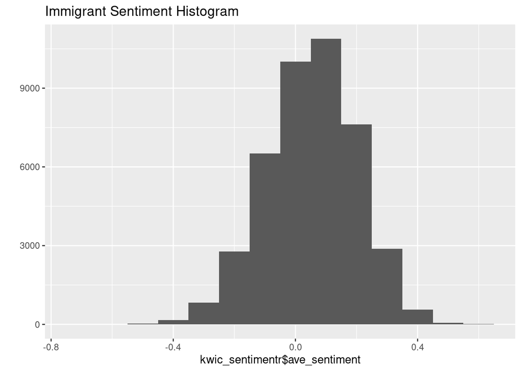